# CSCI2000U Final Project - Albert Galuego, Jevon Rambarran, Moiz Abdul

```python
import pandas as pd
import numpy as np
from matplotlib import pyplot as pl
import seaborn as sns
import scipy.stats as stats
from matplotlib.pyplot import figure
color = sns.color_palette()
sns.set(rc={'figure.figsize':(25,15)})
```

```python
data = pd.read_csv('googleplaystore.csv')
data.head()
```

|  | App | Category | Rating | Reviews | Size | Installs | Type | Price | Content Rating | Genres | Last Updated | Current Ver | Android Ver |
| --- | --- | --- | --- | --- | --- | --- | --- | --- | --- | --- | --- | --- | --- |
| 0 | Photo Editor & Candy Camera & Grid & ScrapBook | ART_AND_DESIGN | 4.1 | 159 | 19M | 10,000+ | Free | 0 | Everyone | Art & Design | 07-Jan-18 | 1.0.0 | 4.0.3 and up |
| 1 | Coloring book moana | ART_AND_DESIGN | 3.9 | 967 | 14M | 500,000+ | Free | 0 | Everyone | Art & Design;Pretend Play | 15-Jan-18 | 2.0.0 | 4.0.3 and up |
| 2 | U Launcher Lite – FREE Live Cool Themes, Hide ... | ART_AND_DESIGN | 4.7 | 87510 | 8.7M | 5,000,000+ | Free | 0 | Everyone | Art & Design | 01-Aug-18 | 1.2.4 | 4.0.3 and up |
| 3 | Sketch - Draw & Paint | ART_AND_DESIGN | 4.5 | 215644 | 25M | 50,000,000+ | Free | 0 | Teen | Art & Design | 08-Jun-18 | Varies with device | 4.2 and up |
| 4 | Pixel Draw - Number Art Coloring Book | ART_AND_DESIGN | 4.3 | 967 | 2.8M | 100,000+ | Free | 0 | Everyone | Art & Design;Creativity | 20-Jun-18 | 1.1 | 4.4 and up |

```python
print(len(data))
```

```
10841
```

- There are **10841** apps on the Google Play Store

```python
# Average rating across all categories
```

```python
groups = data.groupby('Category').filter(lambda x: len(x) >= 170).reset_index()
print('Average rating across all categories = ', np.nanmean(list(groups.Rating)))
```

```
Average rating across all categories =  4.187854642037909
```

- The average rating of (active) apps on Google Play Store is **4.18**.

# Rating by payment method

- Seperate the Data into two dataframes; paid, and free applications
- Plot the mean of both dataframes
- Create two dataframes, one for paid application, one for free applications. Both having the aggragated mean for their respective category. This csv file denotes free applications with a 0 in the price column, so that will be parameter used to create the dataframes.

```
<BarContainer object of 1 artists>
```

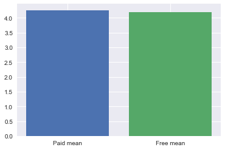

```python
free = pd.DataFrame((data[data['Price'] == "0"])['Rating'].agg([np.mean]))
paid = pd.DataFrame((data[data['Price'] != "0"])['Rating'].agg([np.mean]))
paid = paid.append(free)
pl.bar("Paid "+ paid.index, paid['Rating'])
pl.bar("Free "+ free.index, free['Rating'])
```

- There is a slight difference between the average ratings of paid and free applications on the google play store, paid apps tend to be rated slightly higher than free apps.

# Ratio of paid to free apps

- Show the relation between paid apps and free apps for each category by sorting categories in alphabetical order
- Show how many apps are paid and how many apps are free download.

```python
new_data = data.groupby(['Category', 'Type']).agg({'App' : 'count'}).reset_index()

outer_group_names = data['Category'].sort_values().value_counts()[:5].index
outer_group_values = data['Category'].sort_values().value_counts()[:5].values

outer_group_names = ['GAME', 'FAMILY', 'MEDICAL', 'TOOLS']
outer_group_values = [len(data.App[data.Category == category]) for category in outer_group_names]

inner_group_names = ['Paid', 'Free'] * 4
inner_group_values = []
print(new_data)
```

```
               Category  Type   App
0                   1.9     0     1
1        ART_AND_DESIGN  Free    62
2        ART_AND_DESIGN  Paid     3
3     AUTO_AND_VEHICLES  Free    82
4     AUTO_AND_VEHICLES  Paid     3
5                BEAUTY  Free    53
6   BOOKS_AND_REFERENCE  Free   203
7   BOOKS_AND_REFERENCE  Paid    28
8              BUSINESS  Free   446
9              BUSINESS  Paid    14
10               COMICS  Free    60
11        COMMUNICATION  Free   360
12        COMMUNICATION  Paid    27
13               DATING  Free   227
```

[output cut: 49 more lines]

# Showing paid to free ratio using pie api

- use the pie api to graph the ratio between paid and free apps in Game, Family, Tools, and Medical.
- an outside ring is used to plot the percentage that each category takes up in the pie graph
- an inside ring is used to illustrate the ratio between paid and free apps in each respective category

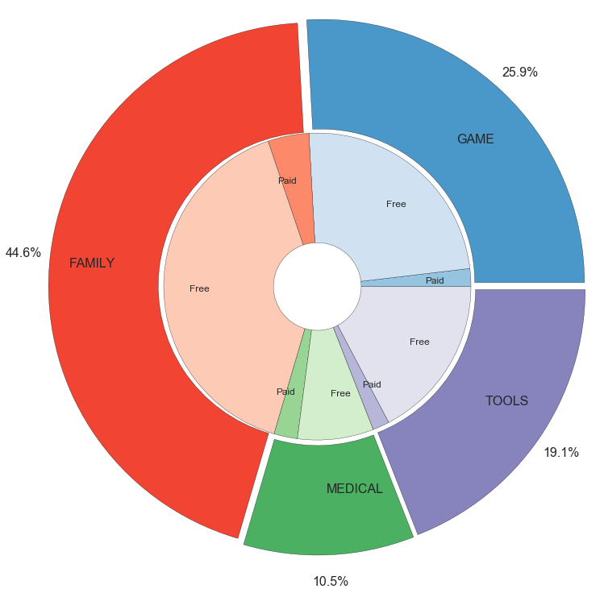

```python
new_data = data.groupby(['Category', 'Type']).agg({'App' : 'count'}).reset_index()

outer_group_names = ['GAME', 'FAMILY', 'MEDICAL', 'TOOLS']
outer_group_values = [len(data.App[data.Category == category]) for category in outer_group_names]

a, b, c, d=[pl.cm.Blues, pl.cm.Reds, pl.cm.Greens, pl.cm.Purples]

inner_group_names = ['Paid', 'Free'] * 4
inner_group_values = []

for category in outer_group_names:
    for t in ['Paid', 'Free']:
        x = new_data[new_data.Category == category]
        try:
            inner_group_values.append(int(x.App[x.Type == t].values[0]))
        except:
            inner_group_values.append(0)

explode = (0.025, 0.025, 0.025, 0.025)
# outside ring
fig, ax = pl.subplots(figsize=(10, 10))
ax.axis('equal')
mypie, texts, _ = ax.pie(outer_group_values, radius=1.2, labels=outer_group_names, autopct='%1.1f%%', pctdistance = 1.1,
                                 labeldistance= 0.75,  explode = explode, colors=[a(0.6), b(0.6), c(0.6), d(0.6)], textprops={'fontsize': 16})
pl.setp( mypie, width=0.5, edgecolor='black')

# inside ring
mypie2, _ = ax.pie(inner_group_values, radius=1.2-0.5, labels=inner_group_names, labeldistance= 0.7,
                   textprops={'fontsize': 12}, colors = [a(0.4), a(0.2), b(0.4), b(0.2), c(0.4), c(0.2), d(0.4), d(0.2)])
pl.setp( mypie2, width=0.5, edgecolor='black')
pl.margins(0,0)

# display graph
pl.tight_layout()
pl.show()
```

- The majority of the top categories of apps are free download favoured

# The mean and median of all application ratings

- Using the loc[] combined with mean/median will allow us to get the median and mean values

```python
mean = data.loc[:, 'Rating'].mean()
median = data.loc[:, 'Rating'].median()

print("Mean: " + str(mean))
print("Median: " + str(median))
```

[output not shown]

- The mean value of all application ratings is **4.19**.
- The median value of all application ratings is **4.3**.

```python
data.head()
```

# Highest rated paid application(s)

- First set index to be the application name
- Using loc we will find the maximum rating
- Create a boolean mask table when data is equal to the highest rated value
- From the new table, we will search for which of those application are "paid"

```python
data = data.set_index('App')
highestRated = data.loc[:, 'Rating'].max()
highestRatedPaid = data[data.loc[:,'Rating'] >= highestRated].loc[:,'Type']
highestRatedPaid = pd.DataFrame(highestRatedPaid[highestRatedPaid == 'Paid'])
highestRatedPaid.head()
```

[output not shown]

- The highest rated paid application is "Super Hearing Secret Voirces Recorder Pro".

# Distribution of ratings across app categories

- Plot the distribution of ratings in each category using the loc api for pinpointing categories in the data and hist api for creating a histogram for each category.
- dropna for dropping missing values

```
F_onewayResult(statistic=17.458034645387226, pvalue=7.792539500402071e-29)
```

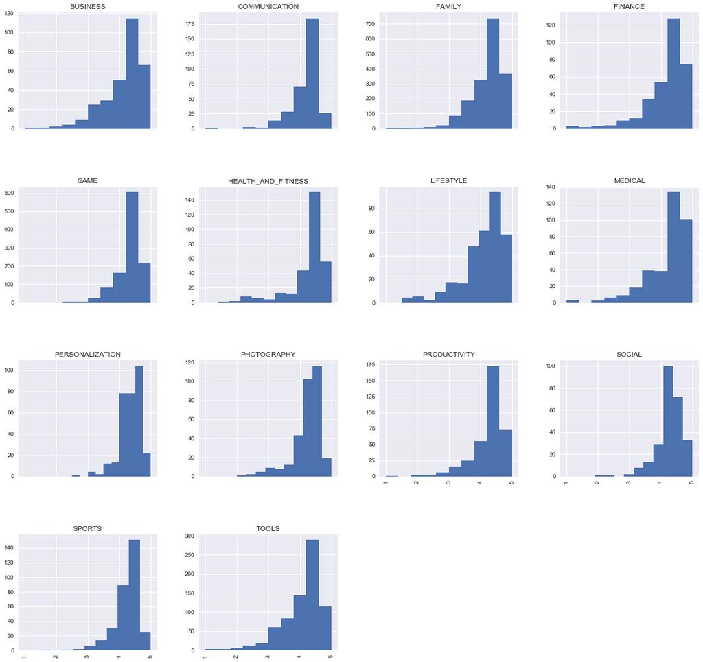

```python
f = stats.f_oneway(data.loc[data.Category == 'BUSINESS']['Rating'].dropna(),
               data.loc[data.Category == 'FAMILY']['Rating'].dropna(),
               data.loc[data.Category == 'GAME']['Rating'].dropna(),
               data.loc[data.Category == 'PERSONALIZATION']['Rating'].dropna(),
               data.loc[data.Category == 'LIFESTYLE']['Rating'].dropna(),
               data.loc[data.Category == 'FINANCE']['Rating'].dropna(),
               data.loc[data.Category == 'EDUCATION']['Rating'].dropna(),
               data.loc[data.Category == 'MEDICAL']['Rating'].dropna(),
               data.loc[data.Category == 'TOOLS']['Rating'].dropna(),
               data.loc[data.Category == 'PRODUCTIVITY']['Rating'].dropna()
              )

print(f)

groups = data.groupby('Category').filter(lambda x: len(x) > 286).reset_index()
array = groups['Rating'].hist(by=groups['Category'], sharex=True, figsize=(20,20))
```

- The average rating for apps across each category varies significantly

# Average rating for an app by category

- To compute the categorical mean we must use groupby and aggregation
- In order to compute this, we must group category and rating
- Then we will use aggregation and numpy's mean function to get the average mean for all categories.

```python
categoricalMean = data.groupby(['Category'])['Rating'].agg([np.mean])
categoricalMean.head()
```

| Category | mean |
| --- | --- |
| 1.9 | 1.900000 |
| ART_AND_DESIGN | 4.358065 |
| AUTO_AND_VEHICLES | 4.190411 |
| BEAUTY | 4.278571 |
| BOOKS_AND_REFERENCE | 4.346067 |

# Bar graph of category vs mean

- Using categorical mean which was computed earlier, we will use the bar graph from pandas dataframe.

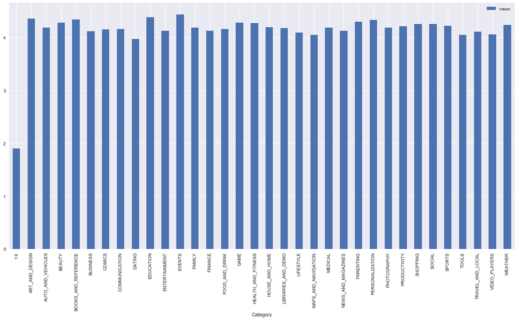

```python
categoricalMean.plot.bar(figsize=(20,10))
```

- The categorical mean is distributed around the 4 - 4.5 rating.

# Highest rated categories

- Sort and display the highest rated app categories on average through use of groupby and agg api.
- Only the top 5 categories are printed

```python
groups = data.groupby('Category').filter(lambda x: len(x) >= 170).reset_index()
c = ['hsl('+str(h)+',50%'+',50%)' for h in np.linspace(0, 720, len(set(groups.Category)))]

data_sorted = data.groupby('Category').agg({'Rating':'median'}).reset_index().sort_values(by='Rating', ascending=False)

print(data_sorted.head())
```

```
               Category  Rating
16   HEALTH_AND_FITNESS     4.5
11               EVENTS     4.5
4   BOOKS_AND_REFERENCE     4.5
15                 GAME     4.4
23            PARENTING     4.4
```

- The highest rated categories are Health, and Fitness, Events, Books and Reference, Games, and Parenting.

# Best category for an application based on the average rating

- Create a dataframe of categorical mean comparing it to maximum categorical mean
- Also, we must drop the NaN values in order to get the best category

```python
categoricalMean[categoricalMean >= categoricalMean.max()].dropna()
```

| Category | mean |
| --- | --- |
| EVENTS | 4.435556 |

- The best category for an application based on average rating is Events.

# Constructing the DataFrame for most recent updated application by its rating

- Find the maximum value for last updated application
- Create a dataframe of the rating for the apps that have been most recentely updated
- Locate updated maximum value
- Compare the maximum value to all the values creating a new dataframe.
- Locate the rating for those values that have been most recentely updated

```python
x = (data.loc[:, 'Last Updated']).max()
RecentUpdateRating = pd.DataFrame(data[data.loc[:, 'Last Updated'] >= x].loc[:, 'Rating']).fillna("N/A")
RecentUpdateRating
```

[output not shown]

# Comparing the two variables rating and number of reviews

```
    * Set the index to be rating
    * Create a dataframe of rating and reviews.
    * In the data set, some of the reviews do not exist so we must drop them
      using dropna()
```

```python
ratingVsReviews = data.set_index('Rating')
#Next line sets index to rating, also droping apps with nan rating
ratingVsReviews = pd.DataFrame(ratingVsReviews.loc[:, 'Reviews']).reset_index().dropna().set_index('Rating')
ratingVsReviews = ratingVsReviews.head(9000)
ratingVsReviews
```

| Rating | Reviews |
| --- | --- |
| 4.1 | 159 |
| 3.9 | 967 |
| 4.7 | 87510 |
| 4.5 | 215644 |
| 4.3 | 967 |
| 4.4 | 167 |
| 3.8 | 178 |
| 4.1 | 36815 |
| 4.4 | 13791 |
| 4.7 | 121 |
| 4.4 | 13880 |
| 4.4 | 8788 |
| 4.2 | 44829 |
| 4.6 | 4326 |
| 4.4 | 1518 |
| 3.2 | 55 |
| 4.7 | 3632 |
| 4.5 | 27 |
| 4.3 | 194216 |
| 4.6 | 224399 |
| 4.0 | 450 |
| 4.1 | 654 |
| 4.7 | 7699 |
| 4.7 | 118 |
| 4.8 | 192 |
| 4.7 | 20260 |
| 4.1 | 203 |
| 3.9 | 136 |
| 4.1 | 223 |
| 4.2 | 1120 |
| ... | ... |
| 4.5 | 53 |
| 4.5 | 104 |
| 4.1 | 5015 |
| 4.1 | 41074 |
| 3.6 | 9 |
| 4.7 | 2317 |
| 4.6 | 216 |
| 4.9 | 10 |
| 4.6 | 688 |
| 4.1 | 981 |
| 4.5 | 166 |
| 3.9 | 751 |
| 3.9 | 53 |
| 4.6 | 169 |
| 3.8 | 729 |
| 4.7 | 175 |
| 3.9 | 4354 |
| 4.1 | 1463 |
| 3.9 | 100 |
| 4.0 | 105 |
| 4.3 | 20 |
| 4.0 | 1007 |
| 4.4 | 16 |
| 4.1 | 4585 |
| 5.0 | 2 |
| 4.8 | 12 |
| 4.6 | 13819 |
| 5.0 | 104 |
| 4.2 | 76 |
| 4.7 | 42 |

9000 rows × 1 columns

# Scatter plot of rating and reviews

- Step 1: Create numpy arrays for reviews and and rating
- Step 2: One variable is int and other is float, so have to convert to same type
- Step 3: Using matplotlip, plot the points of the rating and reviews, and label.

```
Text(0.5,1,'Rating vs Reviews')
```

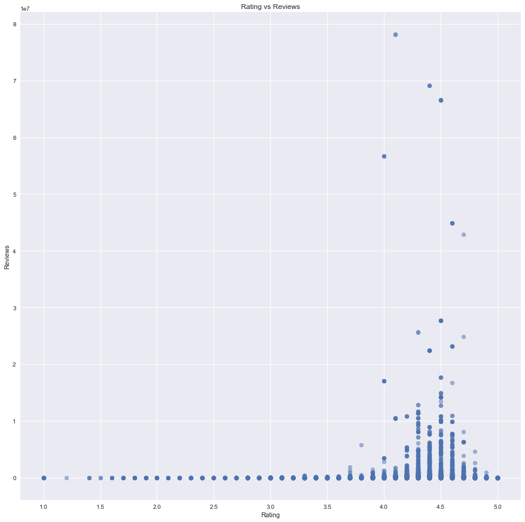

```python
reviews = ratingVsReviews.loc[:,'Reviews'].tolist()
reviews = np.array(reviews)
ratingVsReviews = ratingVsReviews.reset_index()
rating = ratingVsReviews.loc[:,'Rating'].tolist()
rating = np.array(rating)
rating = rating.astype(float)
reviews = reviews.astype(float)
pl.figure(figsize=(15,15))
pl.scatter(rating, reviews,alpha=0.5)
pl.xlabel('Rating')
pl.ylabel('Reviews')
pl.title('Rating vs Reviews')
```

- There does not seem to be a correlation between number of reviews and average rating of an app.

# Correlation coefficient between rating and number of reviews

- Create the numpy arrays for both variables
- Change both variables to the same type.
- Using np.corrcoef function calculate pearsons correlation coefficient.

```python
rating = np.array(rating)
rating = rating.astype(float)
reviews = np.array(reviews)
reviews = reviews.astype(float)
np.corrcoef(rating,reviews)[0,1] # Very weak, positive correlation between the two.
```

```
0.06898057752015785
```

- The correlation coefficient is 0.069, which shows us that the two variables; rating and number of reviews have a positive weak correlation.

# Rating by Maturity

- Create a new dataframe that uses the Maturity rating as the index
- aggragate important information about the ratings of each category
- Plot the mean of each category

```python
data = data.set_index("Content Rating")
RatingByMaturity = pd.DataFrame(data.groupby(['Content Rating'])['Rating'].agg([np.mean, np.std, np.max, np.min]).fillna(0.0))
RatingByMaturity
```

| Content Rating | mean | std | amax | amin |
| --- | --- | --- | --- | --- |
| Adults only 18+ | 4.300000 | 0.435890 | 4.6 | 3.8 |
| Everyone | 4.186375 | 0.537377 | 5.0 | 1.0 |
| Everyone 10+ | 4.257179 | 0.367259 | 5.0 | 1.8 |
| Mature 17+ | 4.123427 | 0.505765 | 5.0 | 1.0 |
| Teen | 4.233487 | 0.391595 | 5.0 | 2.0 |
| Unrated | 4.100000 | 0.000000 | 4.1 | 4.1 |

- Resize the plot to prevent overlapping of labels and overall make it readable. Plot the mean rating of each maturity rating tier and plot the standard deviation of each category using the same plot size.

```
<BarContainer object of 6 artists>
```

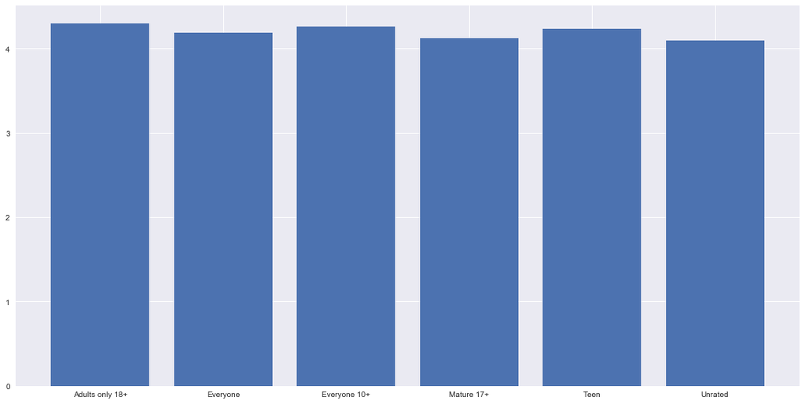

```python
figure(figsize=(18,9))
pl.bar(RatingByMaturity.index, RatingByMaturity['mean'])
```

```
<BarContainer object of 6 artists>
```

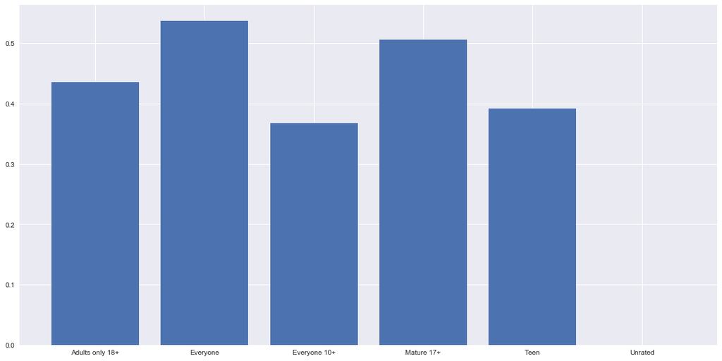

```python
figure(figsize=(18,9))
pl.bar(RatingByMaturity.index, RatingByMaturity['std'])
```

- The mean ratings standard deviation of the apps by their content rating is very low, at **0.078**. This means that there is little deviance of rating based on the content rating of applications on the google playstore. Although it should be noted that the highest rating belongs to **Adult only (18+)** applications. The lowest standard deviation is for **Everyone 10+** at **0.367** and highest for **Everyone** at **0.537**. These cateogries are rather similar in restrictiveness. **Unrated** has only one entry so it does not have a standard deviation value.

# What install range has the highest rating?

- Find which installation range (i.e. 50,000+ installations) yields the highest mean rating
- Create a dataframe that uses the install range as the index and shows the mean
- Create a new dataframe **ByInstalls** that has the aggragated mean, standard deviation, max, and min of each install range. The index of this dataframe will be the install ranges.

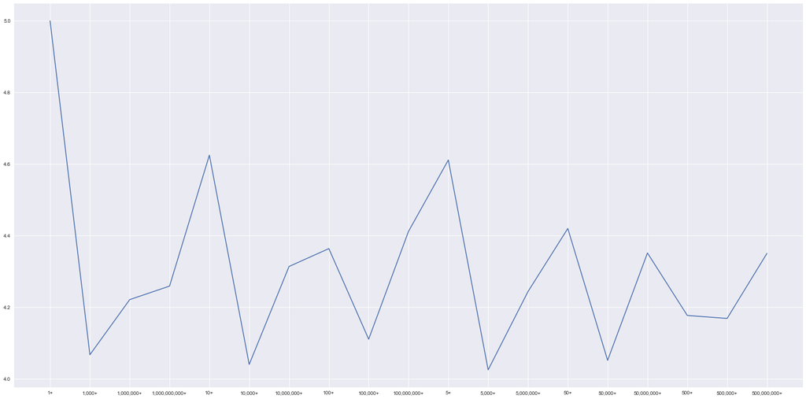

```python
ByInstalls = pd.DataFrame(data.groupby(['Installs'])['Rating'].agg([np.mean, np.std, np. max, np.min]))
ByInstalls.sort_index(inplace=True)
ByInstalls=ByInstalls.drop('Free')
figure(figsize=(28,14))
pl.plot(ByInstalls.index, ByInstalls['mean'])
```

# Adding Restrictions

- The low install applications have the greatest mean rating. This is likely due to a lack of sample size. Removing the means of applications that have less than 1000 installs will show a more accurate graph. The graph will be replotted without these columns to prevent it from skewing the graph.

```python
ByInstalls=ByInstalls.drop('1+')
ByInstalls=ByInstalls.drop('100+')
ByInstalls=ByInstalls.drop('10+')
ByInstalls=ByInstalls.drop('5+')
ByInstalls=ByInstalls.drop('50+')
ByInstalls=ByInstalls.drop('500+')
```

# Plot of the mean with the lowest install ranges being dropped.

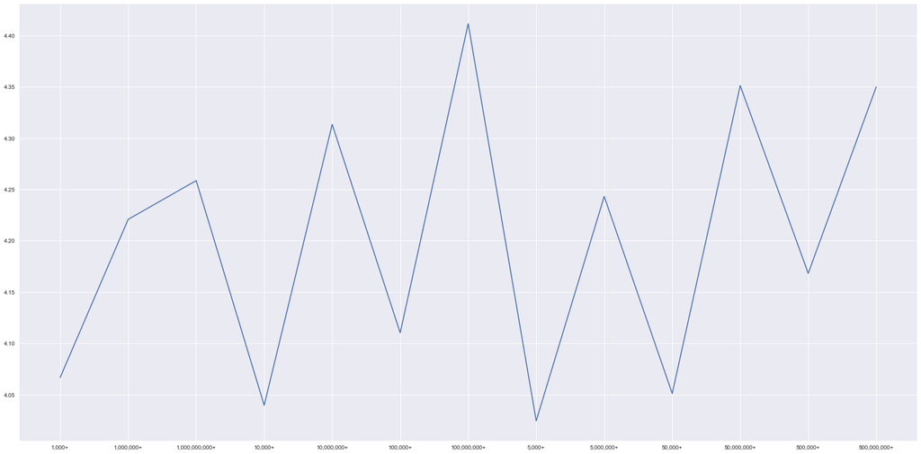

```python
figure(figsize=(28,14))
pl.plot(ByInstalls.index, ByInstalls['mean'])
```

# Plot of the standard deviation with the reduced dataframe.

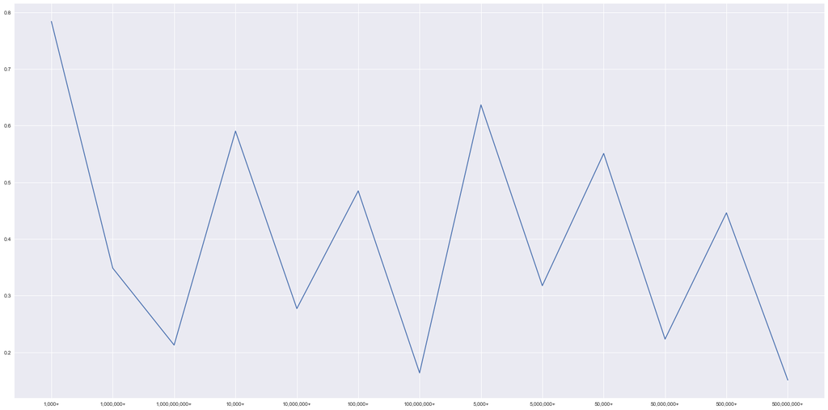

```python
figure(figsize=(28,14))
pl.plot(ByInstalls.index, ByInstalls['std'])
```

- From this graph it is fair to say that applications with a greater amount of installs tend to have a higher rating, they also have a lower standard deviation. This is likely because those applications tend to have a higher budget and a larger development team, whereas lower installed applications tend be independently produced. This leads to a gap between how polished those application are.

# Conclusion

- **10841** apps on the Google Play Store.
- The average rating of (active) apps on Google Play Store is 4.18.
- There is a slight difference between the average ratings of paid and free applications on the google play store, paid apps tend to be rated slightly higher than free apps.
- The majority of the top categories have more applications that are free download.
- The highest rated paid application is "Super Hearing Secret Voirces Recorder Pro".
- The mean for each app category is distributed around the 4 - 4.5 rating.
- The highest rated categories are Health, and Fitness, Events, Books and Reference, Games, and Parenting.
- The best category for an application based on average rating is "Events".
- There does not seem to be a significant correlation between number of reviews and average rating of an app.
- There is little deviance of rating based on the content rating of applications.
- Applications with a greater amount of installs tend to have a higher rating.